# scRNAseq analysis of AGS

Sayaka Matsushima 2026-04-23

```r
library(Seurat)
```

#データの読み込み

```r
seurat_obj <-readRDS("Integration#1.rds")
```

seurat_obj内のorig.iedntを確認する

```r
table(seurat_obj$orig.ident)
```

```
##
## SeuratProject
##         57273
```

Sampleを確認する

```r
table(seurat_obj$Sample)
```

```
##
##   AGS(5)1T    AGS(5)2 AGS(5)2bis   AGS(5)2T
##      14365       8696        962       2013
##         C1      C1bis         C2    C3fresh
##      13907       1680      13483       2167
```

SampleID_paperを確認する

```r
table(seurat_obj$SampleID_paper)
```

```
##
##                      C1
##                   13907
##                  C1_bis
##                    1680
##                      C2
##                   13483
##                      C3
##                    2167
##                      P1
##                   14365
##      P2_after_treatment
##                    2013
##     P2_before_treatment
##                    8696
## P2_before_treatment_bis
##                     962
```

C1,C2,P1,P2_before_treatmentだけを比較したいため抜き出す

```r
seurat_obj <- UpdateSeuratObject(seurat_obj)
```

[output not shown]

[output cut: 33 more lines]

[output not shown]

```r
seurat_obj2 <- subset(seurat_obj, SampleID_paper %in% c("C1", "C2", "P1", "P2_before_treatment"))
```

抜き出し後のSampleID_paperを確認する

```r
table(seurat_obj2$SampleID_paper)
```

```
##
##                      C1
##                   13907
##                  C1_bis
##                       0
##                      C2
##                   13483
##                      C3
##                       0
##                      P1
##                   14365
##      P2_after_treatment
##                       0
##     P2_before_treatment
##                    8696
## P2_before_treatment_bis
##                       0
```

=C1,C2,P1,P2_before_treatmentだけが抜き出せていることが確認された。

seurat_obj2$SampleID_paperの要素から、要素数が0のものを削除する

```r
seurat_obj2$SampleID_paper <- droplevels(seurat_obj2$SampleID_paper)
```

P2_before_treatmentをP2に変更する

```r
levels(seurat_obj2$SampleID_paper)[levels(seurat_obj2$SampleID_paper) == "P2_before_treatment"] <- "P2"
```

処理ができているかを確認する

```r
table(seurat_obj2$SampleID_paper)
```

```
##
##    C1    C2    P1    P2
## 13907 13483 14365  8696
```

UMAPでクラスタリングの結果を確認する

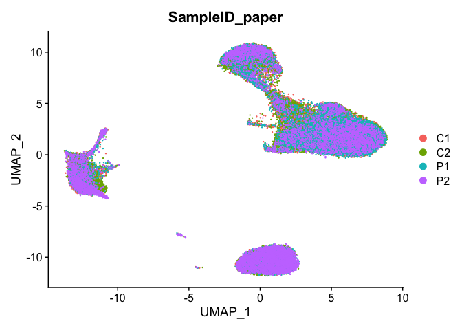

```r
DimPlot(seurat_obj2, reduction = "umap", group.by = "SampleID_paper")
```

C1,C2,P1,P2の４つのグループそれぞれ単体でUMAPをかく

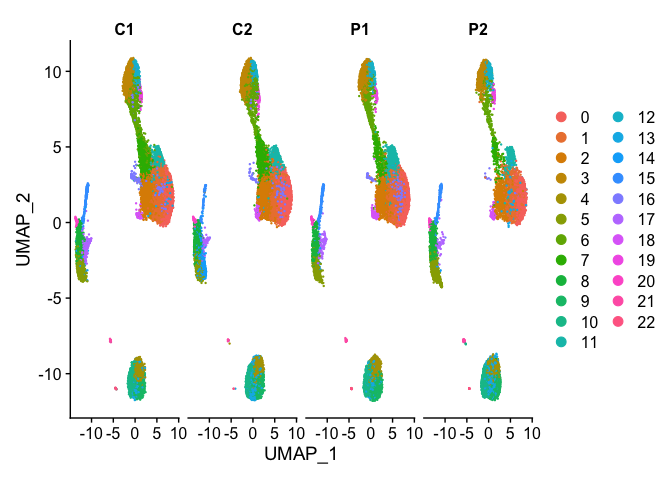

```r
DimPlot(seurat_obj2, reduction = "umap", split.by = "SampleID_paper")
```

MacroClusterを確認する

```r
table(seurat_obj2$MacroCluster)
```

```
##
## Monocytes/cDC             B           CD4
##          6755          8223         22912
##           CD8   NK/MAIT/Tgd           pDC
##          4105          8248           170
##   Plasmablast
##            38
```

MacroClusterをグループ分けしてUMAPをかく

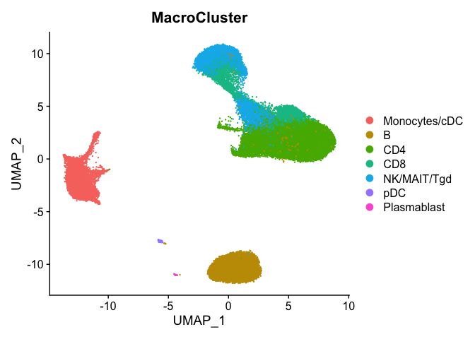

```r
DimPlot(seurat_obj2, reduction = "umap", group.by = "MacroCluster")
```

split.byをSampleID_paperにして、group.byをMacroClusterにしてUMAPをかく

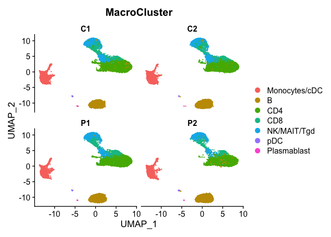

```r
DimPlot(seurat_obj2, reduction = "umap", group.by = "MacroCluster", split.by = "SampleID_paper",ncol=2)
```

クラスターごとの細胞数を確認する

```r
table(seurat_obj2$MacroCluster, seurat_obj2$SampleID_paper)
```

```
##
##                   C1   C2   P1   P2
##   Monocytes/cDC 1760 2599  951 1445
##   B             1501 1414 1938 3370
##   CD4           6317 5464 8871 2260
##   CD8           1408  953 1265  479
##   NK/MAIT/Tgd   2866 3037 1304 1041
##   pDC             42   14   24   90
##   Plasmablast     13    2   12   11
```

サンプルごとに一万細胞にスケーリングする

```r
table_raw <- table(seurat_obj2$MacroCluster, seurat_obj2$SampleID_paper)
table_scaled <- sweep(table_raw, 2, colSums(table_raw) / 10000, FUN = "/")
table_scaled <- round(table_scaled, 1)
table_scaled
```

```
##
##                     C1     C2     P1     P2
##   Monocytes/cDC 1265.5 1927.6  662.0 1661.7
##   B             1079.3 1048.7 1349.1 3875.3
##   CD4           4542.3 4052.5 6175.4 2598.9
##   CD8           1012.4  706.8  880.6  550.8
##   NK/MAIT/Tgd   2060.8 2252.5  907.8 1197.1
##   pDC             30.2   10.4   16.7  103.5
##   Plasmablast      9.3    1.5    8.4   12.6
```

NK/MAIT/Tgdをぬきだす

```r
NK_MAIT_Tgd <- subset(seurat_obj2, MacroCluster %in% c("NK/MAIT/Tgd"))
```

DEGを見つける。(C1,C2)vs(P1,P2)

```r
DEG <- FindMarkers(NK_MAIT_Tgd, ident.2 = c("C1", "C2"), ident.1 = c("P1", "P2"), group.by = "SampleID_paper")
head(DEG)
```

```
##                p_val avg_log2FC pct.1 pct.2
## TMSB4X  0.000000e+00  0.7484184 0.999 0.995
## TMSB10 8.670157e-259  0.8304430 0.973 0.876
## B2M    3.036399e-257  0.5808277 1.000 0.999
## RPL28  5.831237e-252 -1.0736929 0.653 0.893
## IFI44L 9.632141e-231  6.1080025 0.183 0.003
## FTH1   1.129547e-196 -1.2602002 0.644 0.837
##            p_val_adj
## TMSB4X  0.000000e+00
## TMSB10 1.504879e-254
## B2M    5.270277e-253
## RPL28  1.012128e-247
## IFI44L 1.671851e-226
## FTH1   1.960555e-192
```

DEGの中で、p_val_adjが0.05未満、abs(avg_log2FC)>=1のものを抜き出す

```r
DEG_sig <- DEG[DEG$p_val_adj < 0.05 & abs(DEG$avg_log2FC) >= 1, ]
head(DEG_sig)
```

```
##                p_val avg_log2FC pct.1 pct.2
## RPL28  5.831237e-252  -1.073693 0.653 0.893
## IFI44L 9.632141e-231   6.108003 0.183 0.003
## FTH1   1.129547e-196  -1.260200 0.644 0.837
## GNLY   1.024065e-170   1.143122 0.821 0.670
## GZMB   4.123534e-158   1.495313 0.616 0.357
## PABPC1 1.153838e-140  -1.433955 0.357 0.621
##            p_val_adj
## RPL28  1.012128e-247
## IFI44L 1.671851e-226
## FTH1   1.960555e-192
## GNLY   1.777470e-166
## GZMB   7.157218e-154
## PABPC1 2.002716e-136
```

avg_log2FCの順でソートし、20遺伝子を表示する

```r
DEG_sig <- DEG_sig[order(DEG_sig$avg_log2FC, decreasing = TRUE), ]
head(DEG_sig, 20)
```

```
##                  p_val avg_log2FC pct.1 pct.2
## IFI27     2.533342e-99   7.114289 0.078 0.001
## BANK1     1.753210e-14   6.448675 0.011 0.000
## IFI44L   9.632141e-231   6.108003 0.183 0.003
## TRGV5     1.034018e-14   5.500572 0.012 0.000
## RSAD2     1.848380e-25   4.789892 0.020 0.001
## LGALS3BP  1.059692e-19   4.283440 0.020 0.002
## CX3CR1    1.743227e-85   3.760889 0.092 0.008
## MX1       5.872472e-78   3.731355 0.085 0.008
## OAS1      1.880916e-45   3.709603 0.048 0.004
## VPREB3    7.120348e-19   3.606887 0.018 0.001
## IGHM      9.107550e-67   3.562267 0.077 0.008
## TCL1A     6.193443e-32   3.493674 0.034 0.003
## FAM184B   3.529856e-15   3.427074 0.015 0.001
## MKI67     2.812244e-10   3.324408 0.010 0.001
## MEF2C     8.528566e-35   3.304638 0.041 0.004
## SPATS2L   3.611121e-17   3.276170 0.021 0.003
## IFI44     1.124336e-35   3.244079 0.043 0.005
## EPSTI1    8.519136e-47   3.243571 0.058 0.007
## USP18     2.487681e-42   3.242193 0.048 0.005
## CCDC34    2.029232e-11   3.048646 0.014 0.002
##              p_val_adj
## IFI27     4.397121e-95
## BANK1     3.043047e-10
## IFI44L   1.671851e-226
## TRGV5     1.794744e-10
## RSAD2     3.208233e-21
## LGALS3BP  1.839307e-15
## CX3CR1    3.025719e-81
## MX1       1.019285e-73
## OAS1      3.264707e-41
## VPREB3    1.235879e-14
## IGHM      1.580797e-62
## TCL1A     1.074996e-27
## FAM184B   6.126772e-11
## MKI67     4.881213e-06
## MEF2C     1.480303e-30
## SPATS2L   6.267823e-13
## IFI44     1.951510e-31
## EPSTI1    1.478667e-42
## USP18     4.317867e-38
## CCDC34    3.522138e-07
```

```r
tail(DEG_sig, 20)
```

```
##                      p_val avg_log2FC pct.1
## LMNA          2.515356e-16  -2.893248 0.006
## RGCC          7.656086e-35  -2.955139 0.017
## PLK3          7.485114e-19  -3.018768 0.007
## PPP1R14B      4.944070e-20  -3.081571 0.005
## PTGDS         2.196965e-41  -3.182187 0.020
## S100B         4.377186e-09  -3.403921 0.003
## FKBP8         2.209806e-12  -3.501235 0.003
## PMEPA1        3.465529e-09  -3.573442 0.002
## TRAF4         1.362374e-07  -3.596953 0.001
## RP11-372K14.2 1.282109e-07  -3.922465 0.001
## G0S2          1.662727e-09  -3.949552 0.001
## CXCL8         9.301852e-07  -3.956223 0.000
## DUSP4         5.871008e-18  -4.696509 0.002
## SLC7A5        3.177104e-28  -5.097214 0.001
## HLA-DRB5      1.098067e-12  -5.110879 0.001
## HBB           7.157675e-07  -5.592085 0.001
## KRT81         3.273421e-09  -5.880038 0.000
## NBL1          2.181009e-10  -6.120349 0.000
## RASGEF1B      1.139692e-08  -6.131631 0.000
## N4BP3         1.328769e-21  -7.035131 0.000
##               pct.2    p_val_adj
## LMNA          0.040 4.365904e-12
## RGCC          0.094 1.328867e-30
## PLK3          0.047 1.299191e-14
## PPP1R14B      0.045 8.581422e-16
## PTGDS         0.112 3.813272e-37
## S100B         0.020 7.597482e-05
## FKBP8         0.026 3.835560e-08
## PMEPA1        0.018 6.015119e-05
## TRAF4         0.015 2.364672e-03
## RP11-372K14.2 0.014 2.225357e-03
## G0S2          0.017 2.885996e-05
## CXCL8         0.011 1.614522e-02
## DUSP4         0.035 1.019031e-13
## SLC7A5        0.053 5.514499e-24
## HLA-DRB5      0.023 1.905916e-08
## HBB           0.013 1.242358e-02
## KRT81         0.016 5.681676e-05
## NBL1          0.018 3.785577e-06
## RASGEF1B      0.015 1.978164e-04
## N4BP3         0.039 2.306345e-17
```

volcano plotをかく

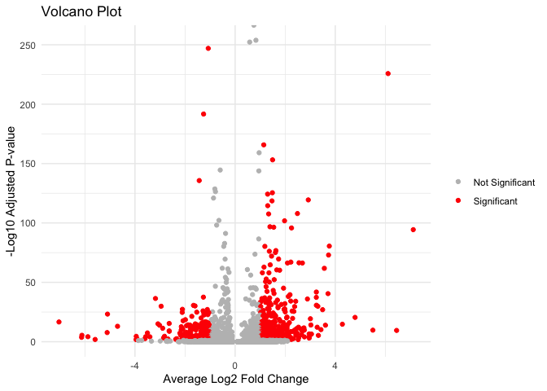

```r
library(ggplot2)
DEG$significant <- "Not Significant"
DEG$significant[DEG$p_val_adj < 0.05 & abs(DEG$avg_log2FC) >= 1] <- "Significant"
ggplot(DEG, aes(x = avg_log2FC, y = -log10(p_val_adj), color = significant)) +
  geom_point() +
  scale_color_manual(values = c("Not Significant" = "grey", "Significant" = "red")) +
  theme_minimal() +
  labs(title = "Volcano Plot", x = "Average Log2 Fold Change", y = "-Log10 Adjusted P-value") +
  theme(legend.title = element_blank())
```

UMAPを確認する、SampleID_paperでsplit

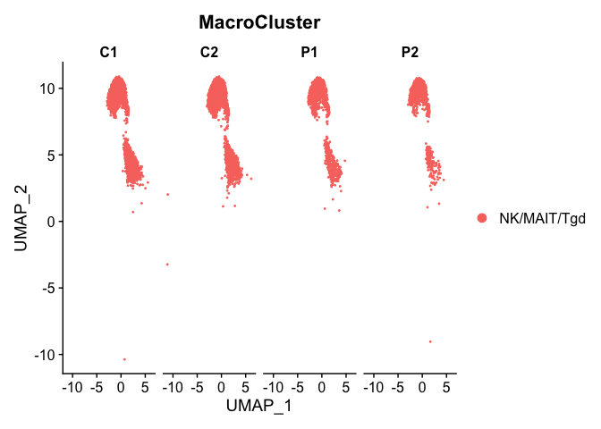

```r
DimPlot(NK_MAIT_Tgd, reduction = "umap", split.by = "SampleID_paper", group.by = "MacroCluster")
```

UMAP上で確認する、MX1をFeaturePlotで確認する

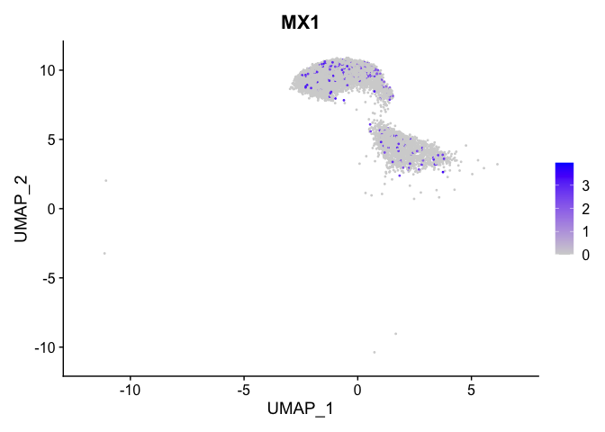

```r
FeaturePlot(NK_MAIT_Tgd, features = "MX1")
```

VlnPlotで MX1を確認する

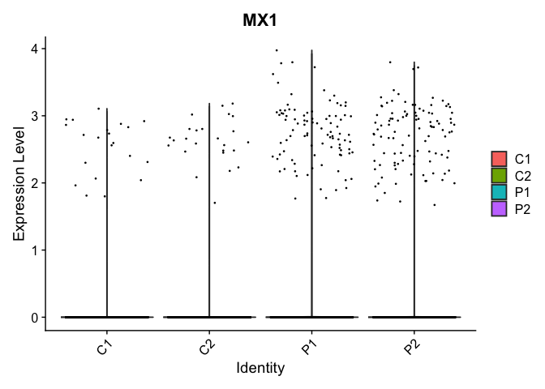

```r
VlnPlot(NK_MAIT_Tgd, features = "MX1", group.by = "SampleID_paper")
```

OAS1をVlnPlotで確認する

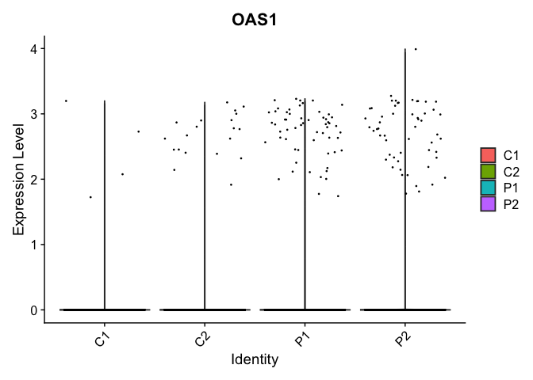

```r
VlnPlot(NK_MAIT_Tgd, features = "OAS1", group.by = "SampleID_paper")
```

IFI33LをVlnPlotで確認する

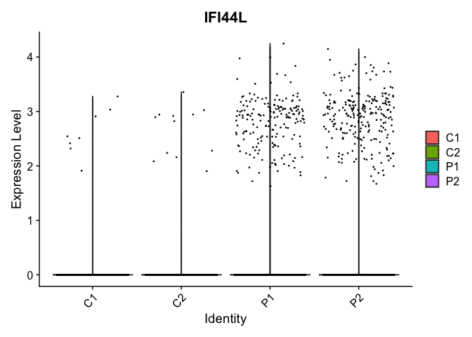

```r
VlnPlot(NK_MAIT_Tgd, features = "IFI44L", group.by = "SampleID_paper")
```

DEG_sigからpct.1>=0.5のものを抜き出す

```r
DEG_sig_pct <- DEG_sig[DEG_sig$pct.1 >= 0.5, ]
DEG_sig_pct
```

```
##                p_val avg_log2FC pct.1 pct.2
## GZMB   4.123534e-158   1.495313 0.616 0.357
## CD52   1.720627e-119   1.300749 0.537 0.304
## MYL12A 3.144844e-129   1.297312 0.557 0.305
## GNLY   1.024065e-170   1.143122 0.821 0.670
## RPL28  5.831237e-252  -1.073693 0.653 0.893
## FTH1   1.129547e-196  -1.260200 0.644 0.837
##            p_val_adj
## GZMB   7.157218e-154
## CD52   2.986492e-115
## MYL12A 5.458507e-125
## GNLY   1.777470e-166
## RPL28  1.012128e-247
## FTH1   1.960555e-192
```

RPL28をVlnPlotで確認する

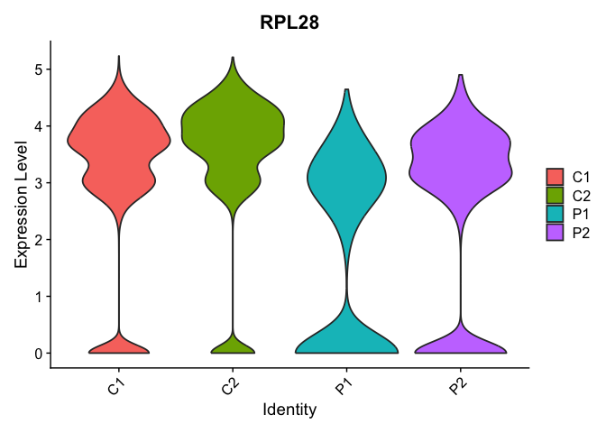

```r
VlnPlot(NK_MAIT_Tgd, features = "RPL28", group.by = "SampleID_paper", pt.size = 0)
```

CD52をVlnPlotで確認する

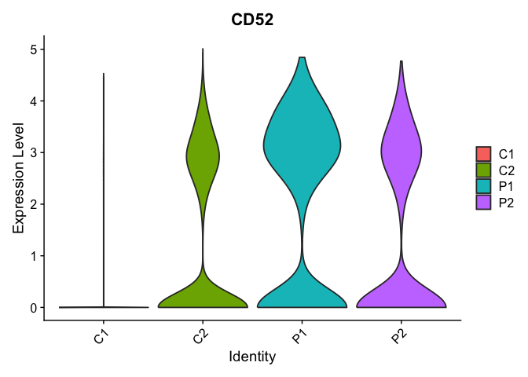

```r
VlnPlot(NK_MAIT_Tgd, features = "CD52", group.by = "SampleID_paper", pt.size = 0)
```

I型インターフェロン応答の評価を行う。 [https://www.gsea-msigdb.org/gsea/msigdb/cards/GOBP_RESPONSE_TO_TYPE_I_INTERFERONから、GOBP_RESPONSE_TO_TYPE_I_INTERFERON.v2026.1.Hs.grpを読み込む](https://www.gsea-msigdb.org/gsea/msigdb/cards/GOBP_RESPONSE_TO_TYPE_I_INTERFERON%E3%81%8B%E3%82%89%E3%80%81GOBP_RESPONSE_TO_TYPE_I_INTERFERON.v2026.1.Hs.grp%E3%82%92%E8%AA%AD%E3%81%BF%E8%BE%BC%E3%82%80)

```r
IFNI_gene_set <- read.table("./GOBP_RESPONSE_TO_TYPE_I_INTERFERON.v2026.1.Hs.grp", header = FALSE, stringsAsFactors = FALSE, comment.char = "#" )
IFNI_genes <- IFNI_gene_set$V1
head(IFNI_genes)
```

```
## [1] "GOBP_RESPONSE_TO_TYPE_I_INTERFERON"
## [2] "ADAR"
## [3] "ADRM1"
## [4] "AZI2"
## [5] "CACTIN"
## [6] "CDC37"
```

seurat_obj2の遺伝子に絞り、module scoreを計算する

```r
IFNI_genes_in_data <- IFNI_genes[IFNI_genes %in% rownames(seurat_obj2)]
seurat_obj2 <- AddModuleScore(seurat_obj2, features = list(IFNI_genes_in_data), name = "IFNI_Score")
```

IFNI_ScoreをVlnPlotで確認する

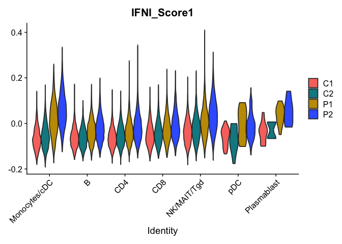

```r
VlnPlot(seurat_obj2, features = "IFNI_Score1", split.by = "SampleID_paper", group.by = "MacroCluster", pt.size = 0)
```

C1とC2をCtrl,P1とP2をAGSとしてSampleID_paper2を作成する

```r
seurat_obj2$SampleID_paper2 <- ifelse(seurat_obj2$SampleID_paper %in% c("C1", "C2"), "Ctrl", "AGS")
table(seurat_obj2$SampleID_paper2)
```

```
##
##   AGS  Ctrl
## 23061 27390
```

VlnPlotでIFNI_Score1を確認する

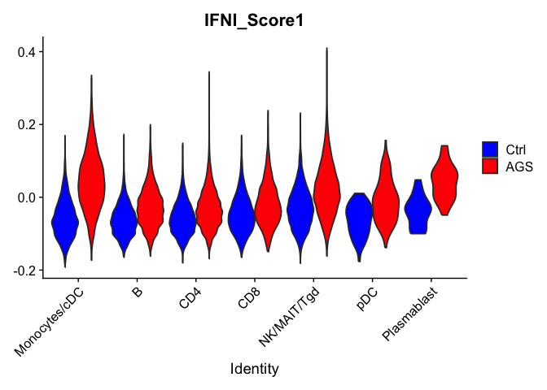

```r
seurat_obj2$SampleID_paper2 <- factor(seurat_obj2$SampleID_paper2, levels = c("Ctrl", "AGS"))
VlnPlot(seurat_obj2, features = "IFNI_Score1", split.by = "SampleID_paper2", group.by = "MacroCluster", pt.size = 0, cols = c("Ctrl" = "blue", "AGS" = "red"))
```

MacroClusterごとに2群を比較する、結果はttest_resultに保存する

```r
ttest_result<-list()
library(dplyr)
```

```r
for (cluster in unique(seurat_obj2$MacroCluster)) {
  cluster_cells <- subset(seurat_obj2, MacroCluster == cluster)
  test_result <- t.test(cluster_cells$IFNI_Score1 ~ cluster_cells$SampleID_paper2)
  cat("MacroCluster:", cluster, "p-value:", test_result$p.value, "\n")
  ttest_result[[cluster]] <- test_result$p.value
}
```

```
## MacroCluster: CD4 p-value: 0
## MacroCluster: CD8 p-value: 2.964317e-50
## MacroCluster: NK/MAIT/Tgd p-value: 5.268703e-189
## MacroCluster: B p-value: 5.768246e-217
## MacroCluster: Monocytes/cDC p-value: 0
## MacroCluster: pDC p-value: 4.325201e-10
## MacroCluster: Plasmablast p-value: 5.260713e-06
```

平均の差を確認する、結果はmean_diff_resultに保存する

```r
mean_diff_result <- list()
for (cluster in unique(seurat_obj2$MacroCluster)) {
  cluster_cells <- subset(seurat_obj2, MacroCluster == cluster)
  mean_ctrl <- mean(cluster_cells$IFNI_Score1[cluster_cells$SampleID_paper2 == "Ctrl"], na.rm = TRUE)
  mean_ags <- mean(cluster_cells$IFNI_Score1[cluster_cells$SampleID_paper2 == "AGS"], na.rm = TRUE)
  cat("MacroCluster:", cluster, "Mean Ctrl:", mean_ctrl, "Mean AGS:", mean_ags, "\n")
  mean_diff_result[[cluster]] <- list(mean_ctrl = mean_ctrl, mean_ags = mean_ags, diff = mean_ags - mean_ctrl)
}
```

```
## MacroCluster: CD4 Mean Ctrl: -0.05781428 Mean AGS: -0.03025712
## MacroCluster: CD8 Mean Ctrl: -0.04604825 Mean AGS: -0.01937667
## MacroCluster: NK/MAIT/Tgd Mean Ctrl: -0.02860278 Mean AGS: 0.02253401
## MacroCluster: B Mean Ctrl: -0.0618201 Mean AGS: -0.02646034
## MacroCluster: Monocytes/cDC Mean Ctrl: -0.05875559 Mean AGS: 0.04365781
## MacroCluster: pDC Mean Ctrl: -0.06247763 Mean AGS: -0.009725095
## MacroCluster: Plasmablast Mean Ctrl: -0.03892327 Mean AGS: 0.04265781
```

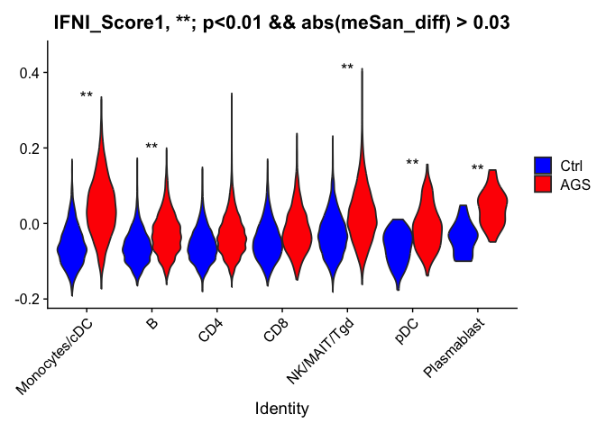

```r
library(Seurat)

p <- VlnPlot(
  seurat_obj2,
  features = "IFNI_Score1",
  split.by = "SampleID_paper2",
  group.by = "MacroCluster",
  pt.size = 0,
  cols = c("Ctrl" = "blue", "AGS" = "red"),
  y.max = max(seurat_obj2$IFNI_Score1, na.rm = TRUE) * 1.1,
) +
labs(
  title = "IFNI_Score1, **; p<0.01 && abs(meSan_diff) > 0.03"
)

annot_df <- data.frame()

for (cluster in names(ttest_result)) {

  p_value <- ttest_result[[cluster]]

  label <- ""
  if (p_value < 0.01　&& abs(mean_diff_result[[cluster]]$diff) > 0.03) {
    label <- "**"
  } else if (p_value < 0.05 && abs(mean_diff_result[[cluster]]$diff) > 0.03) {
    label <- "*"
  }

  if (label != "") {
    y_pos <- max(seurat_obj2$IFNI_Score1[seurat_obj2$MacroCluster == cluster], na.rm = TRUE)

    annot_df <- rbind(
      annot_df,
      data.frame(
        MacroCluster = cluster,
        label = label,
        y = y_pos
      )
    )
  }
}


p + geom_text(
  data = annot_df,
  aes(x = MacroCluster, y = y, label = label),
  inherit.aes = FALSE
)
```